# R for Health Data Science

Week 08: Biostats II

Sam Stewart

2021-04-09

```r
library(Hmisc)
library(kableExtra)
library(tidyverse)
library(ggplot2)
library(boomer)
library(survival)
library(survminer)
library(haven)
library(lme4)
library(mlmRev)

dat = read.csv("data/framinghamFirst.csv",header=TRUE,
               na.strings=".",stringsAsFactors=FALSE)
dat$BMIGroups = cut(dat$BMI,breaks=c(0,18.5,25,30,Inf),
                    labels=c("Underweight","Normal","Overweight","Obese"))
dat$SEX = factor(dat$SEX,levels=1:2,labels=c("Male","Female"))
dat$DIABETES = factor(dat$DIABETES,levels=0:1,labels=c("No Diabetes","Diabetes"))
dat$HYPERTEN = factor(dat$HYPERTEN,levels=0:1,labels=c("Normotensive","Hypertensive"))

#for the survival analysis
dat.lung = lung %>% tibble %>%
  mutate(
    sex = factor(sex,levels=1:2,labels=c("M","F")),
    ageGroup = cut(age,breaks=c(0,50,60,70,100)),
    ph.ecog = factor(ph.ecog)
  )

#for the multilevel models
imm = read_dta("https://stats.idre.ucla.edu/stat/examples/imm/imm10.dta")

dat.imm = imm %>%
  mutate(homework.fact = factor(homework))
```

# 1 Survival Analysis

Survival analysis is the analysis of time to event data

- Time from surgery to infection
- Time from breast cancer diagnosis to death
- Time from entry into addiction treatment to relapse

We need three time points to perform a survival analysis

- Starting time (often 0)
- Stopping time
- Censoring - an indicator if the event occurred

We’ll start with Kaplan Meier curves, then move onto Cox Proportional Hazards Regression. We’ll use a built-in R dataset here called `lung` on the survival rate of patients with advanced lung cancer. See `?lung` for more details.

## 1.1 Kaplan-Meier

The command to fit a Kaplan-Meier curve is `survfit()`, and it uses the formula approach as with `lm()` and `glm()`. The difference here is that our outcome is a combination of either 2 or 3 variables - in this case there is a `time` variable that records the amount of time followed, and a `status` variable that records whether whether the subject died or not. We’ll pass those to a `Surv()` object on the left side of the equation, and then the stratifying variables are on the right.

```r
km.lung00 = survfit(Surv(time,status)~1,data=dat.lung)
km.lung00
```

```
## Call: survfit(formula = Surv(time, status) ~ 1, data = dat.lung)
##
##       n  events  median 0.95LCL 0.95UCL
##     228     165     310     285     363
```

```r
summary(km.lung00)
```

```
## Call: survfit(formula = Surv(time, status) ~ 1, data = dat.lung)
##
##  time n.risk n.event survival std.err lower 95% CI upper 95% CI
##     5    228       1   0.9956 0.00438       0.9871        1.000
##    11    227       3   0.9825 0.00869       0.9656        1.000
##    12    224       1   0.9781 0.00970       0.9592        0.997
##    13    223       2   0.9693 0.01142       0.9472        0.992
##    15    221       1   0.9649 0.01219       0.9413        0.989
##    26    220       1   0.9605 0.01290       0.9356        0.986
##    30    219       1   0.9561 0.01356       0.9299        0.983
##    31    218       1   0.9518 0.01419       0.9243        0.980
##    53    217       2   0.9430 0.01536       0.9134        0.974
##    54    215       1   0.9386 0.01590       0.9079        0.970
##    59    214       1   0.9342 0.01642       0.9026        0.967
##    60    213       2   0.9254 0.01740       0.8920        0.960
```

[output cut: 127 more lines]

```r
km.lung01 = survfit(Surv(time,status)~sex,data=dat.lung)
km.lung01
```

```
## Call: survfit(formula = Surv(time, status) ~ sex, data = dat.lung)
##
##         n events median 0.95LCL 0.95UCL
## sex=M 138    112    270     212     310
## sex=F  90     53    426     348     550
```

```r
summary(km.lung01)
```

```
## Call: survfit(formula = Surv(time, status) ~ sex, data = dat.lung)
##
##                 sex=M
##  time n.risk n.event survival std.err lower 95% CI upper 95% CI
##    11    138       3   0.9783  0.0124       0.9542        1.000
##    12    135       1   0.9710  0.0143       0.9434        0.999
##    13    134       2   0.9565  0.0174       0.9231        0.991
##    15    132       1   0.9493  0.0187       0.9134        0.987
##    26    131       1   0.9420  0.0199       0.9038        0.982
##    30    130       1   0.9348  0.0210       0.8945        0.977
##    31    129       1   0.9275  0.0221       0.8853        0.972
##    53    128       2   0.9130  0.0240       0.8672        0.961
##    54    126       1   0.9058  0.0249       0.8583        0.956
##    59    125       1   0.8986  0.0257       0.8496        0.950
##    60    124       1   0.8913  0.0265       0.8409        0.945
```

[output cut: 142 more lines]

The printout of the model reports the basic summary stats, and the summary reports the lifetable. We can also plot the data, either with the basic `plot()` function, or with the ggplot-friendly `survminer::ggsurvplot()`. `ggsurvplot()` doesn’t follow the `tidyverse` principles perfectly, but it’s still a marked improvement from the base library, see [this blog](https://rpkgs.datanovia.com/survminer/) for a good exploration of the options.

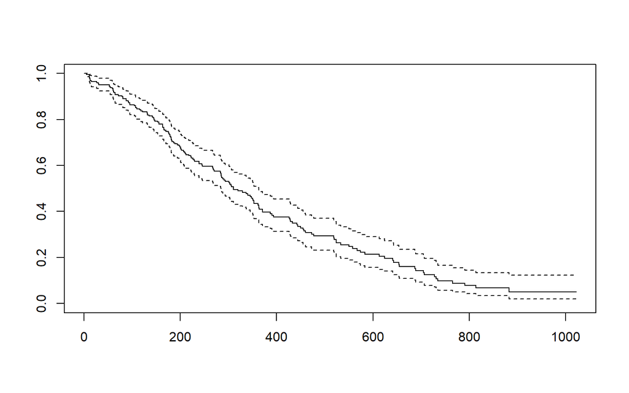

```r
plot(km.lung00)
```

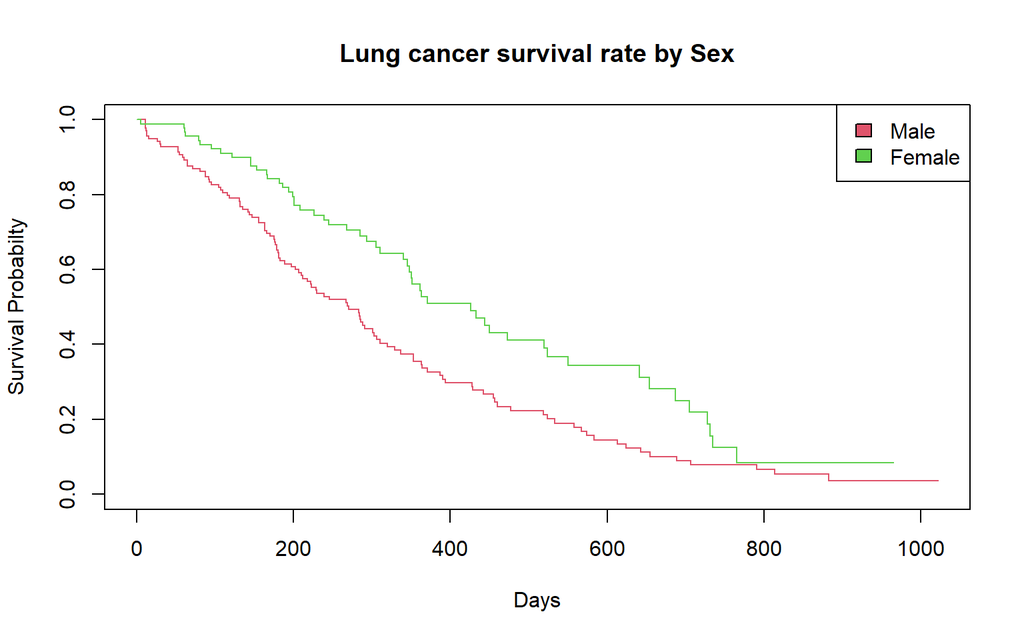

```r
plot(km.lung01,col=2:3,xlab='Days',ylab='Survival Probabilty',main='Lung cancer survival rate by Sex')
legend("topright",fill=2:3,legend=c("Male","Female"))
```

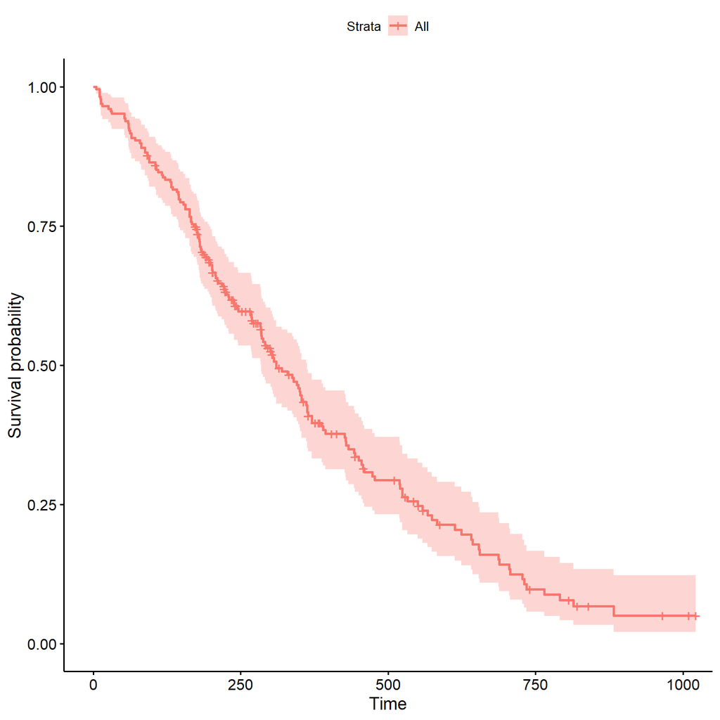

```r
ggsurvplot(km.lung00)
```

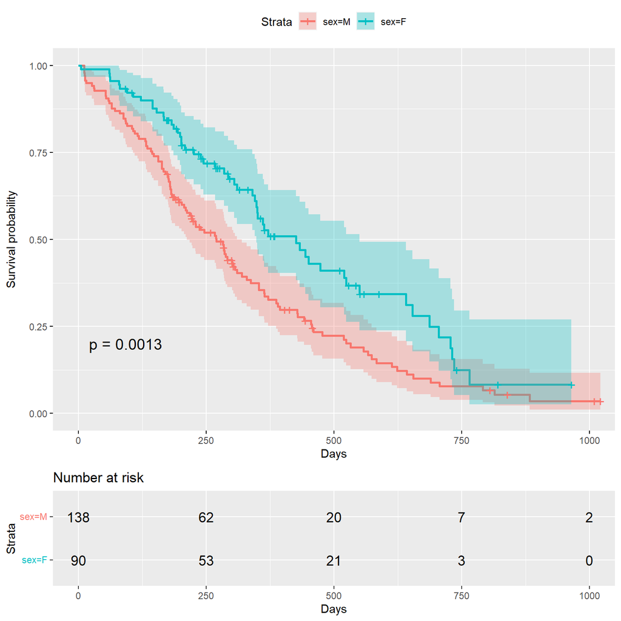

```r
ggsurvplot(km.lung01,
           ggtheme=theme_grey(),
           conf.int=TRUE,
           pval=TRUE,
           risk.table=TRUE)+
  labs(x="Days",Strata="")
```

## 1.2 Cox PH Regression

We’ll use the `coxph()` command to fit Cox PH regression models - they follow the same general format as `survfit()`, but produce a regression model. We’ll evaluate them using the `car::Anova()` command, which will evaluate the varialbes using log-likelihood tests.

```r
#simple model predicting survival with sex
mod.lung01 = coxph(Surv(time,status)~sex,data=dat.lung)
#Anova evaluates each variables
car::Anova(mod.lung01)
```

```
## Analysis of Deviance Table
##  Cox model: response is Surv(time, status)
## Terms added sequentially (first to last)
##
##       loglik  Chisq Df Pr(>|Chi|)
## NULL -749.91
## sex  -744.59 10.634  1   0.001111 **
## ---
## Signif. codes:  0 '***' 0.001 '**' 0.01 '*' 0.05 '.' 0.1 ' ' 1
```

```r
#getting the coefficient table
summary(mod.lung01)
```

```
## Call:
## coxph(formula = Surv(time, status) ~ sex, data = dat.lung)
##
##   n= 228, number of events= 165
##
##         coef exp(coef) se(coef)      z Pr(>|z|)
## sexF -0.5310    0.5880   0.1672 -3.176  0.00149 **
## ---
## Signif. codes:  0 '***' 0.001 '**' 0.01 '*' 0.05 '.' 0.1 ' ' 1
##
##      exp(coef) exp(-coef) lower .95 upper .95
## sexF     0.588      1.701    0.4237     0.816
##
## Concordance= 0.579  (se = 0.021 )
## Likelihood ratio test= 10.63  on 1 df,   p=0.001
## Wald test            = 10.09  on 1 df,   p=0.001
## Score (logrank) test = 10.33  on 1 df,   p=0.001
```

```r
#full model predicting survival with sex, ageGroup and ECOG score
mod.lung02 = coxph(Surv(time,status)~sex+ageGroup+ph.ecog,data=dat.lung)
car::Anova(mod.lung02)
```

```
## Analysis of Deviance Table (Type II tests)
##          LR Chisq Df Pr(>Chisq)
## sex       11.6240  1  0.0006511 ***
## ageGroup   3.4347  3  0.3293293
## ph.ecog   18.0770  3  0.0004240 ***
## ---
## Signif. codes:  0 '***' 0.001 '**' 0.01 '*' 0.05 '.' 0.1 ' ' 1
```

```r
summary(mod.lung02)
```

```
## Call:
## coxph(formula = Surv(time, status) ~ sex + ageGroup + ph.ecog,
##     data = dat.lung)
##
##   n= 227, number of events= 164
##    (1 observation deleted due to missingness)
##
##                     coef exp(coef) se(coef)      z Pr(>|z|)
## sexF             -0.5606    0.5709   0.1688 -3.321 0.000897 ***
## ageGroup(50,60]   0.2478    1.2812   0.2929  0.846 0.397446
## ageGroup(60,70]   0.1207    1.1283   0.2821  0.428 0.668697
## ageGroup(70,100]  0.4590    1.5825   0.3009  1.525 0.127136
## ph.ecog1          0.4309    1.5386   0.2015  2.138 0.032507 *
## ph.ecog2          0.9485    2.5819   0.2341  4.053 5.07e-05 ***
## ph.ecog3          2.1541    8.6205   1.0343  2.083 0.037284 *
## ---
## Signif. codes:  0 '***' 0.001 '**' 0.01 '*' 0.05 '.' 0.1 ' ' 1
##
##                  exp(coef) exp(-coef) lower .95 upper .95
## sexF                0.5709     1.7517    0.4101    0.7947
## ageGroup(50,60]     1.2812     0.7805    0.7217    2.2747
## ageGroup(60,70]     1.1283     0.8863    0.6491    1.9614
## ageGroup(70,100]    1.5825     0.6319    0.8775    2.8541
## ph.ecog1            1.5386     0.6499    1.0366    2.2838
## ph.ecog2            2.5819     0.3873    1.6320    4.0847
## ph.ecog3            8.6205     0.1160    1.1353   65.4566
##
## Concordance= 0.642  (se = 0.025 )
## Likelihood ratio test= 32.94  on 7 df,   p=3e-05
## Wald test            = 33.07  on 7 df,   p=3e-05
## Score (logrank) test = 35.36  on 7 df,   p=1e-05
```

That’s good, but we need to get this in production-quality, so we’ll format using our `tidyverse` skills.

```r
#in multiple steps like a sane person
#a) extract the coefficients
coef = summary(mod.lung02)$coefficients %>% as.data.frame() %>%
  rownames_to_column()
#b) extract the confidence intervals
ci = summary(mod.lung02)$conf.int %>% as.data.frame %>%
              rownames_to_column()
#c) join the two, and reduce to useful columns
out01 = left_join(coef,ci) %>%
  select(rowname,'exp(coef)','lower .95','upper .95','Pr(>|z|)') %>%
  rename(RR=`exp(coef)`,
         variable = rowname)
#d) print the columns
out01 %>% kable(digits=c(0,3,2,2,4)) %>% kable_styling()
```

| variable | RR | lower .95 | upper .95 | Pr(>\|z\|) |
| --- | --- | --- | --- | --- |
| sexF | 0.571 | 0.41 | 0.79 | 0.0009 |
| ageGroup(50,60] | 1.281 | 0.72 | 2.27 | 0.3974 |
| ageGroup(60,70] | 1.128 | 0.65 | 1.96 | 0.6687 |
| ageGroup(70,100] | 1.583 | 0.88 | 2.85 | 0.1271 |
| ph.ecog1 | 1.539 | 1.04 | 2.28 | 0.0325 |
| ph.ecog2 | 2.582 | 1.63 | 4.08 | 0.0001 |
| ph.ecog3 | 8.620 | 1.14 | 65.46 | 0.0373 |

```r
#OR
#do it all at once
summary(mod.lung02)$coefficients %>% as.data.frame %>%
  rownames_to_column() %>%
  left_join(summary(mod.lung02)$conf.int %>% as.data.frame %>%
              rownames_to_column()
              ) %>%
  select(rowname,'exp(coef)','lower .95','upper .95','Pr(>|z|)') %>%
  rename(RR=`exp(coef)`,
         variable = rowname) %>%
  kable(digits=c(0,3,2,2,4)) %>% kable_styling() %>%
  pack_rows("Sex",1,1)%>%
  pack_rows("Age Group",2,4)%>%
  pack_rows("ECOG Score",5,7)
```

| variable | RR | lower .95 | upper .95 | Pr(>\|z\|) |
| --- | --- | --- | --- | --- |
| **Sex** |  |  |  |  |
| sexF | 0.571 | 0.41 | 0.79 | 0.0009 |
| **Age Group** |  |  |  |  |
| ageGroup(50,60] | 1.281 | 0.72 | 2.27 | 0.3974 |
| ageGroup(60,70] | 1.128 | 0.65 | 1.96 | 0.6687 |
| ageGroup(70,100] | 1.583 | 0.88 | 2.85 | 0.1271 |
| **ECOG Score** |  |  |  |  |
| ph.ecog1 | 1.539 | 1.04 | 2.28 | 0.0325 |
| ph.ecog2 | 2.582 | 1.63 | 4.08 | 0.0001 |
| ph.ecog3 | 8.620 | 1.14 | 65.46 | 0.0373 |

# 2 Multilevel Models

There are several ways to fit multilevel models in R, but the most common are with the `lmer()` and `glmer()` functions from the `lme4` library. I’ll focus on their use for multilevel models with random intercepts and/or random slopes - for longitudinal data I prefer `gee()`, but if you like mixed-effects for longitudinal data you can use `lmer()`.

For this section I’m going to follow along with the UCLA Stats page on multilevel modeling, available [here](https://stats.idre.ucla.edu/r/examples/mlm-imm/r-kreft-chp-3/).

# 3 Syntax

The traditional syntax is `y~x` for a simple model, or `y~x1+x2+...+xk` for a multiple model. With multilevel modeling we want to be able to adjust for random slopes and/or random intercepts, which we control with additional random components in brackets `()` at the end of the equation. For a **random intercept** the format will be

```
y ~ x1+x2+x3+(1|group)
```

The `1` in the random component refers to the intercept, in a similar fashion to a regression model `y~1` that fits y predicted with only an intercept. This fits a model that predicts `y` with `x1, x2, x3`, but adds a random intercept for each level of `group`.

If we also want random slopes the format would be

```
y ~ x1+x2+x3+(x2|group)
```

In this equation we’re adding a random slope for the variable `x2`, while also including a random intercept by default. Note that `x2` doesn’t need to be in both variable lists, that was our choice for this model.

## 3.1 `lmer` example from UCLA stats

I’m having a hard time finding the provenance of the `imm10` dataset - it’s from the UCLA Stats textbook *Introduction to Multilevel Modeling*, but I can’t find a help file or description of it, so I’m going to infer most of it.

It has 260 subjects from 10 different schools - we’re going to focus on their math scores as a function of their dedication to homework.

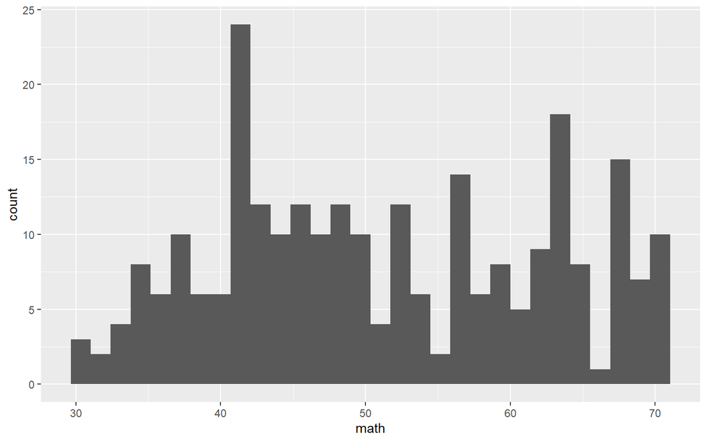

```r
dat.imm %>%
  ggplot(aes(x=math))+
  geom_histogram()
```

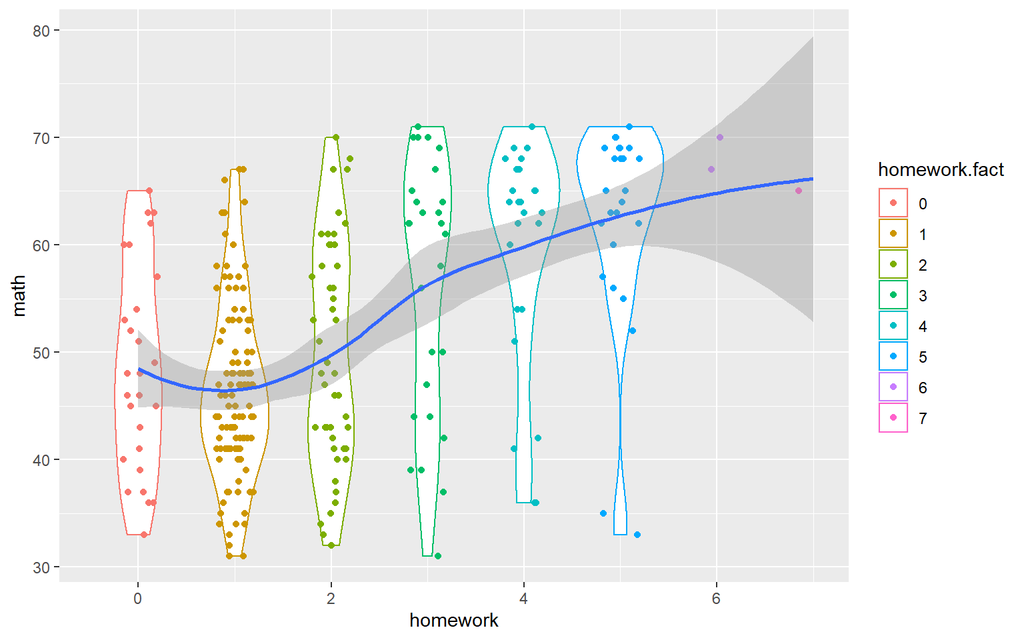

```r
#geom_jitter is like geom_point, but can scatter things a bit randomly, useful for overlapping datapoints
dat.imm %>%
  ggplot(aes(x=homework,y=math))+
  geom_violin(aes(group=homework,colour=homework.fact))+
#  geom_point(aes(colour=homework.fact))+
  geom_jitter(aes(colour=homework.fact),width=0.2,height=0)+
  geom_smooth()
```

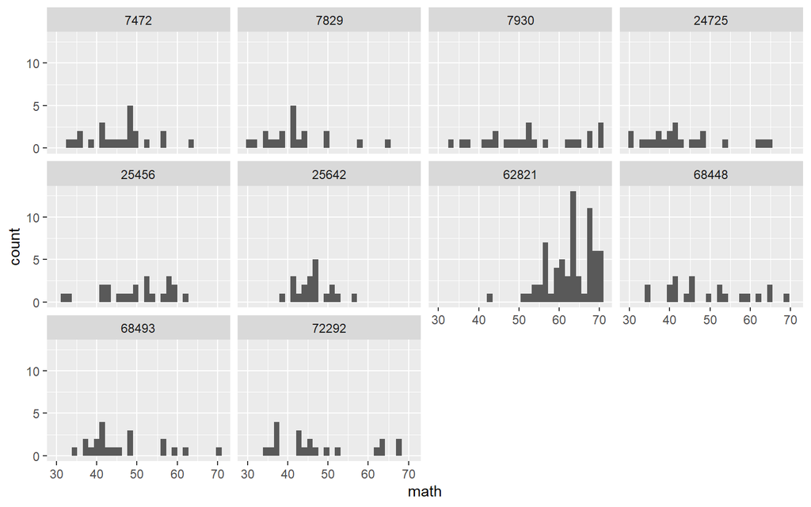

```r
dat.imm %>%
  ggplot(aes(x=math))+
  geom_histogram()+
  facet_wrap(~schid)
```

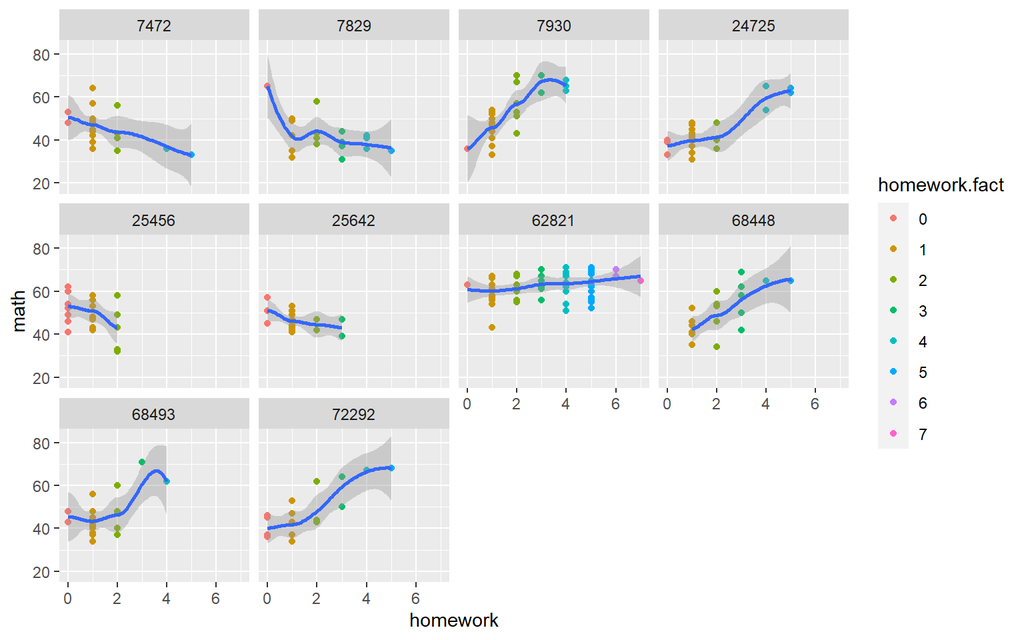

```r
dat.imm %>%
  ggplot(aes(x=homework,y=math))+
  geom_point(aes(colour=homework.fact))+
  geom_smooth()+
  facet_wrap(~schid)
```

The graphics demonstrate a relationship between math score and homework, but probably significant variation between schools. We’ll start with individual linear regression models.

```r
lin.mods = by(dat.imm,dat.imm$schid,function(x){lm(math~homework,data=x)})
```

The `by` function stratifies a dataset by a variable and performs a function on each stratified dataset - in this case I fit a simple linear regression predict math score with homework for each school individually. I want to see how the models differ.

```r
t(sapply(lin.mods,coef))
```

```
##       (Intercept)  homework
## 7472     50.68354 -3.553797
## 7829     49.01229 -2.920123
## 7930     38.75000  7.909091
## 24725    34.39382  5.592664
## 25456    53.93863 -4.718412
## 25642    49.25896 -2.486056
## 62821    59.21022  1.094640
## 68448    36.05535  6.496310
## 68493    38.52000  5.860000
## 72292    37.71392  6.335052
```

These numbers confirm what our last plot showed - that the relationship between math and homework does not seem to be consistent across schools.

Based on the differences in both intercept and slope values, we’ll fit a mixed effects model with a random slope for homework per school (and a random intercept per school).

```r
mod.lme01 = lmer(math~homework+(homework|schid),data=dat.imm)
mod.lme01
```

```
## Linear mixed model fit by REML ['lmerMod']
## Formula: math ~ homework + (homework | schid)
##    Data: dat.imm
## REML criterion at convergence: 1763.954
## Random effects:
##  Groups   Name        Std.Dev. Corr
##  schid    (Intercept) 8.325
##           homework    4.738    -0.81
##  Residual             6.563
## Number of obs: 260, groups:  schid, 10
## Fixed Effects:
## (Intercept)     homework
##       44.77         2.04
```

```r
car::Anova(mod.lme01)
```

```
## Analysis of Deviance Table (Type II Wald chisquare tests)
##
## Response: math
##           Chisq Df Pr(>Chisq)
## homework 1.7236  1     0.1892
```

```r
summary(mod.lme01)
```

```
## Linear mixed model fit by REML ['lmerMod']
## Formula: math ~ homework + (homework | schid)
##    Data: dat.imm
##
## REML criterion at convergence: 1764
##
## Scaled residuals:
##     Min      1Q  Median      3Q     Max
## -2.5110 -0.5357  0.0175  0.6121  2.5708
##
## Random effects:
##  Groups   Name        Variance Std.Dev. Corr
##  schid    (Intercept) 69.31    8.325
##           homework    22.45    4.738    -0.81
##  Residual             43.07    6.563
## Number of obs: 260, groups:  schid, 10
##
## Fixed effects:
##             Estimate Std. Error t value
## (Intercept)   44.771      2.744  16.318
## homework       2.040      1.554   1.313
##
## Correlation of Fixed Effects:
##          (Intr)
## homework -0.804
```

And we can expand the model to other fixed effects as well (including school-level effects)

```r
mod.lme02 = lmer(math~homework+public+(homework|schid),data=dat.imm)
mod.lme02
```

```
## Linear mixed model fit by REML ['lmerMod']
## Formula: math ~ homework + public + (homework | schid)
##    Data: dat.imm
## REML criterion at convergence: 1743.966
## Random effects:
##  Groups   Name        Std.Dev. Corr
##  schid    (Intercept) 6.771
##           homework    4.895    -0.97
##  Residual             6.554
## Number of obs: 260, groups:  schid, 10
## Fixed Effects:
## (Intercept)     homework       public
##      58.041        1.952      -14.661
```

```r
car::Anova(mod.lme02)
```

```
## Analysis of Deviance Table (Type II Wald chisquare tests)
##
## Response: math
##           Chisq Df Pr(>Chisq)
## homework  1.491  1     0.2221
## public   48.403  1   3.47e-12 ***
## ---
## Signif. codes:  0 '***' 0.001 '**' 0.01 '*' 0.05 '.' 0.1 ' ' 1
```

```r
summary(mod.lme02)
```

```
## Linear mixed model fit by REML ['lmerMod']
## Formula: math ~ homework + public + (homework | schid)
##    Data: dat.imm
##
## REML criterion at convergence: 1744
##
## Scaled residuals:
##      Min       1Q   Median       3Q      Max
## -2.63743 -0.56210 -0.05468  0.64216  2.58576
##
## Random effects:
##  Groups   Name        Variance Std.Dev. Corr
##  schid    (Intercept) 45.85    6.771
##           homework    23.96    4.895    -0.97
##  Residual             42.96    6.554
## Number of obs: 260, groups:  schid, 10
##
## Fixed effects:
##             Estimate Std. Error t value
## (Intercept)   58.041      2.943  19.721
## homework       1.952      1.599   1.221
## public       -14.661      2.107  -6.957
##
## Correlation of Fixed Effects:
##          (Intr) homwrk
## homework -0.741
## public   -0.636  0.008
```

```r
mod.lme03 = lmer(math~homework*public+(homework|schid),data=dat.imm)
mod.lme03
```

```
## Linear mixed model fit by REML ['lmerMod']
## Formula: math ~ homework * public + (homework | schid)
##    Data: dat.imm
## REML criterion at convergence: 1738.737
## Random effects:
##  Groups   Name        Std.Dev. Corr
##  schid    (Intercept) 7.200
##           homework    5.222    -0.98
##  Residual             6.554
## Number of obs: 260, groups:  schid, 10
## Fixed Effects:
##     (Intercept)         homework           public  homework:public
##         59.2102           1.0946         -15.9657           0.9512
```

```r
car::Anova(mod.lme03)
```

```
## Analysis of Deviance Table (Type II Wald chisquare tests)
##
## Response: math
##                   Chisq Df Pr(>Chisq)
## homework         1.3112  1     0.2522
## public          48.8206  1  2.805e-12 ***
## homework:public  0.0295  1     0.8637
## ---
## Signif. codes:  0 '***' 0.001 '**' 0.01 '*' 0.05 '.' 0.1 ' ' 1
```

```r
summary(mod.lme03)
```

```
## Linear mixed model fit by REML ['lmerMod']
## Formula: math ~ homework * public + (homework | schid)
##    Data: dat.imm
##
## REML criterion at convergence: 1738.7
##
## Scaled residuals:
##      Min       1Q   Median       3Q      Max
## -2.64023 -0.56436 -0.05373  0.65209  2.58438
##
## Random effects:
##  Groups   Name        Variance Std.Dev. Corr
##  schid    (Intercept) 51.84    7.200
##           homework    27.27    5.222    -0.98
##  Residual             42.96    6.554
## Number of obs: 260, groups:  schid, 10
##
## Fixed effects:
##                 Estimate Std. Error t value
## (Intercept)      59.2102     7.4074   7.993
## homework          1.0946     5.2432   0.209
## public          -15.9657     7.8292  -2.039
## homework:public   0.9512     5.5424   0.172
##
## Correlation of Fixed Effects:
##             (Intr) homwrk public
## homework    -0.964
## public      -0.946  0.912
## homwrk:pblc  0.912 -0.946 -0.963
```

# 4 Breakout Activity

1. There’s another built-in dataset called `veteran` that reports the results of a trial comparing two treatment regimens for people with lung cancer. Use the dataset to
   - Draw a Kaplan-Meier curve survival with treatment
   - Fit a Cox PH model predicting survival with treatment, cancer type and age
2. For mixed effects model there’s a library called `mlmRev` that has a dataset called `Exam` - it records the exam scores for 4059 students from 65 schools in Inner London. I want you to build a model to predict their normalized exam score (`normexam`) based on the available data, see `?Exam` after you install and load the library.